# Geology 590 Final Project: Determination of Cumulative Degree Hours (CDH)

L. Stacy Taylor

April 30, 2017

## Introduction to the Standard Operating Procedure (SOP):

The calculation of Cumulative Degree Hours (CDH) is performed when a sampling strategy is based on accumulated mean tempertures over a period of time, rather than employing dedicated time intervals that may contain variable temperature ranges. This is an important sampling strategy for field studies when temperature strongly affects the outcome of an experiment and yet is an uncontrolled variable.

This project involves downloading data from a weather station located at the UT gardens in order to calculate the CDH. The weather station data is extensive and the file columns utilized are the following: Year, Julian date, Hr.Min, and Ambient. Julian date values range from 1-365, or 1-366 in the case of leap years. Hr.Min consists of hourly notations in the form of: 100, 200…1100, 1200, …2400. Ambient is simply ambient air temperture in degrees C. When supplied a date range, a minimum of two hourly temperture values, a low temperature threshold, and the number of anticipated samples required, the program will provide the following: the total CDH for the duration of the sampling period, the CDH for the sample interval selected, a printout of the calculated sampling schedule, and graphs of both daily degree hours as a function of date, as well as date as a function of CDH in order to visually assess reasonable sampling patterns.

**Important considerations:** This calculator is designed to utilize historical data to propose a sampling schedule. It is not designed to function as a predictive model, except for use as a guide to climate and temperature behavior. It is possible to maintain DH and CDH values that are concurrent with an ongoing experiment, although this does necessitate continual updating of the root Excel .csv file.

The Cumulative Degree Hour Standard Operating Procedure (CDH SOP) follows below in a paragraph-documented cookbook style format. Additionally, there are several points where it is possible to extract internally created dataframes in the event that it is preferable to look at the data during individual steps in the calculation sequence.

## The CDH SOP:

**Step 1: Setup** Download the following test data file that is provided with this markdown document: *Weather2013_15.csv*.

**Note:** If actual Excel spreadsheet data from a weather station is to be utilized, there are some important adjustments to be made to the Excel data prior to use. Spreadsheet files must have any headers removed except column titles. Column titles of interest must read: Year, Julian_day, Hr.Min, and Ambient. Title rows must be unfrozen. If there is a column entitled ID, this title must be changed prior to conversion to .csv file formatting, otherwise the file formatting does not happen correctly (this is an Excel quirk). Finally, resulting data must be saved as a .csv file.

Ensure that the *tidyverse* and *lubridate* packages are installed. These packages are required to run this code.

**Step 2: Downloading data and initial dataframe creation** The following code loads the *tidyverse* and *lubridate* libraries, reads the data file, and creates a dataframe entitled *weatherdata* that contains four columns of data: Year, Julian_day, Hr.Min, Ambient. This dataframe is large and can be printed to the screen by removing the # prior to the final print statement, but will not automatically print here in the interests of brevity.

**Note:** if another file has been created for use, it will need to be entered in the 3rd line: *read.csv(file=“enter_new_filename_here.csv”)*

```r
suppressMessages(library(tidyverse))
suppressMessages(library(lubridate))
weatherdata <- read.csv(file="Weather2013_15.csv") %>%
  select(Year, Julian_day, Hr.Min, Ambient)
#print(weatherdata) #in order to view weatherdata, remove initial #sign
```

The following code converts the Julian_date column into YYYY-MM-DD format in a two-step process. Julian date ranges from 1-365 or 366, but does not contain a zero as a starting point. Therefore, an origin must be set for each year that constitutes the creation of an artificial zero point on 12-31 of the prior year. The output from this code creates a new dataframe entitled *weather1* and adds two columns: one column is the origin, and the next is the date that is created from the combined Julian_day and Year columns. This dataframe is large and can be printed to the screen by removing the # prior to the final print statement, but will not automatically print here in the interests of brevity.

```r
set_origin <- function(yr) {
  as.Date(paste0(yr-1, "-12-31"))
}

weather1 <- mutate(weatherdata,
      origin.date = set_origin(Year),
      date = as.Date(Julian_day, origin.date))
#print(weather1)#in order to view weather1, remove initial #sign
```

**Step 3: Initial Data entry**  
1. Choose a date range and enter it in the first and second lines between the quotes in the first filter statement *date >= ymd(“2014-06-01”) & date <=ymd(“2015-06-01”)*. The first line contains the starting date, and the second line contains the ending date. Formatting is in the form of “YYYY-MM-DD” **Note:** the dates listed will be included in the date range selected.

2. Choose the times at which temperature readings will be taken (100 and 1300 here) and enter these values into the third line *(Hr.Min==XX00)*. Generally this is done at 12-hour intervals at the estimated highest and lowest points of the day.
3. Choose the low temperature threshold. All values below this choice will be reset to the selcted value, in this case 0. *weather2[weather2<0]=X*

```r
weather2 <- filter(weather1, date >= ymd("2014-06-01") &
                date <= ymd("2015-06-01")) %>%
  filter(Hr.Min==100 | Hr.Min==1300)

#This sets the lower temperature threshold (in this case to zero)
weather2[weather2<0]=0
#print(weather2)#in order to view weather2, remove initial #sign
```

**Step 4: Calculations** The following calculates daily means of the Ambient temperatures chosen above by the hourly selections from Step 3, number 2. A new dataframe is created *(calc_CDH)* that contains these means in a column entitled DH (degree hours). A final column, CDH (cumulative degree hours), is a running daily sum of values in the DH column.

```r
calc_CDH <- weather2 %>%
  group_by(date) %>%
  summarise(DH=mean(Ambient)) %>%
  mutate(CDH=cumsum(DH)) %>%
  print(calc_CDH)
```

```
## # A tibble: 366 × 3
##          date     DH     CDH
##        <date>  <dbl>   <dbl>
## 1  2014-06-01 24.850  24.850
## 2  2014-06-02 23.940  48.790
## 3  2014-06-03 23.480  72.270
## 4  2014-06-04 25.205  97.475
## 5  2014-06-05 24.030 121.505
## 6  2014-06-06 23.195 144.700
## 7  2014-06-07 25.365 170.065
## 8  2014-06-08 24.120 194.185
## 9  2014-06-09 22.255 216.440
## 10 2014-06-10 23.975 240.415
## # ... with 356 more rows
```

The following calculation returns the total sum of the DH column, which is the same as the final value in the CDH column. This is the total value for cumulative degree hours for the entire study range.

```r
DHsum <- sum(calc_CDH$DH)
print(DHsum)
```

```
## [1] 5567.616
```

**Step 5: Final data entry** 1. Enter the total number of samples that will be taken, here there are 11. *sample_rate<-XX*

```r
sample_rate <- 11
```

The code below returns the value for the CDH interval between samples. If this interval is too high or too low, adjust the sample rate above.

```r
sample_interval_size <- DHsum/(sample_rate-1)
print(sample_interval_size)
```

```
## [1] 556.7616
```

2. In the start_row line, change the date within the quotes to equal the starting date used in Step 3, number 1, above. The format will be YYYY-MM-DD. *start_row <- filter(calc_CDH, date==“YYYY-MM-DD”)*
3. In the for statement below, enter the value for *sample rate-1* used above (in this case, 10). *for(i in 1:XX)*

This code creates a new dataframe entitled *sample_schedule*. It uses the sample interval size (obtained above), and for each integer multiple of the interval size it returns the last closest value of the CDH. These CDH values are then used to select rows from the *calc_CDH* dataframe from step 4 and these rows are then bound together into the new dataframe.

```r
sample_schedule <- numeric(0)
start_row <- filter(calc_CDH, date=="2014-06-01")
sample_schedule <-rbind(sample_schedule, start_row)

for (i in 1:10) {
  increment <- sample_interval_size*i
  a <-last(calc_CDH$CDH[calc_CDH$CDH <= increment])
  new_row <- filter(calc_CDH, CDH==a)
  sample_schedule <- rbind(sample_schedule, new_row)
}
```

```
## # A tibble: 11 × 3
##          date      DH      CDH
## *      <date>   <dbl>    <dbl>
## 1  2014-06-01 24.8500   24.850
## 2  2014-06-22 24.0750  539.000
## 3  2014-07-14 27.7150 1095.748
## 4  2014-08-07 25.3850 1660.408
## 5  2014-08-30 26.2250 2223.098
## 6  2014-09-23 17.8300 2781.538
## 7  2014-10-24 12.8000 3329.113
## 8  2015-01-15  0.2570 3895.821
## 9  2015-04-05 10.8535 4442.811
## 10 2015-05-07 24.2750 4994.346
## 11 2015-06-01 22.3300 5567.616
```

Degree Hours by Date Within Sampling Timeframe

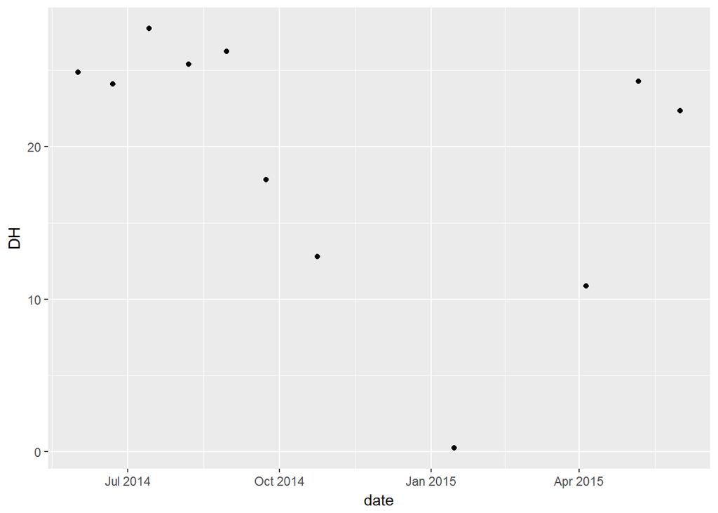

Date as a Function of CDH

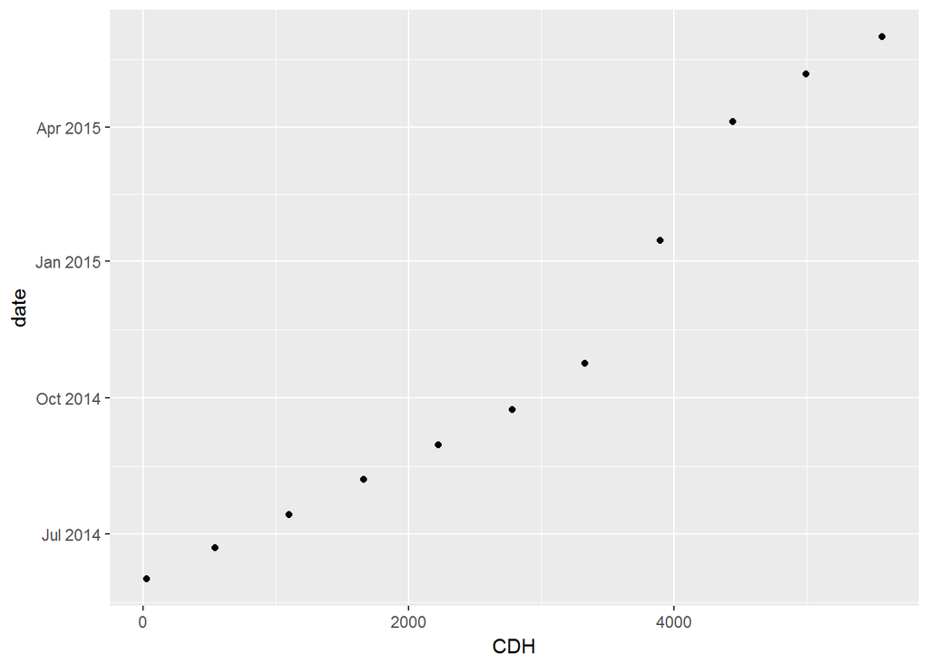

**Discussion**

**Errors**

**Internal Dataframe Outputs**

*Weatherdata:* The weatherdata dataframe is produced by the code in the Step 2. This dataframe contains the following columns: Year, Julian_day, Hr.Min, and Ambient. This is still raw data from the original Excel spreadsheet. This dataframe can be printed according to the instructions in the print statement at the bottom of the code chunk.

*weather1:* The weather1 dataframe is produced by the code in Step 2. This dataframe contains six columns, the same columns in weatherdata (Year, Julian_day, Hr.Min, Ambient), but also two additional columns that transform the Julian dates into actual dates of the form: YYYY-MM-DD. Those columns are: origin.date, and date. This dataframe can be printed according to the instructions in the print statement at the bottom of the code chunk.

*weather2:* The weather 2 dataframe is produced by the code in Step 3, Nos. 2 and 3. This dataframe contains the same columns as weather1, however they have now been filtered according to hours selected for calculating means downstream. This dataframe, after correction for threshold temperature, can be printed according to the instructions in the print statement at the bottom of the code chunk.

*calc_CHD:* This is the first dataframe that is printed to the screen, and contains the following columns: date, DH, CDH. The date column contains the adjusted Julian dates calculated in weather1. The DH (degree hours) column contains the means of the Ambient temperatures filtered in weather 2. The CDH column contains the rolling sum of the daily DH.